# A3: SPL Library Checkouts

### Introduction

The data set I chose was everything checked out that was part of the Geronimo Stilton series. Geronimo Stilton is a popular children’s book series that I enjoyed dearly as a young child and was created by Italian author Elisabetta Dami. The series features a mouse named Geronimo Stilton, who is a journalist and author living in New Mouse City.

### Summary Information

I conducted an analysis and obtained five key values related to Geronimo Stilton books in the SPL. Firstly, I identified the Geronimo Stilton book with the highest number of checkouts in the SPL, which was The amazing voyage : the third adventure in the Kingdom of Fantasy . Secondly, I determined the Geronimo Stilton book with the lowest number of checkouts in the SPL and was Ma che vacanza … a Rocca Taccagna! . Thirdly, I calculated the month in which Geronimo Stilton had the highest number of checkouts in the SPL, which I found it to be 8. Fourthly, I identified the month in which Geronimo Stilton had the lowest number of checkouts in the SPL and discovered it was 12. Lastly, I calculated the Geronimo Stilton book with the highest number of checkouts in the SPL in 2011, which I named Save the white whale! [text by Geronimo Stilton ; illustrations by Sara Copercini (pencils), Riccardo Sisti (ink) and Christian Aliprandi (color) ; translated by Lidia Tramontozzi]., The dragon of fortune : an epic Kingdom of Fantasy adventure .

### The Dataset

- Who collected/published the data?

The City of Seattle published data that was collected by the Seattle Public Library.

- What are the parameters of the data (dates, number of checkouts, kinds of books, etc.)?

I filtered the data to only include Geronimo Stilton books. The creator is listed as either “Geronimo, Stilton”, “Stilton, Geronimo”, “Thea, Stilton”, or “Stilton, Thea.” The data set includes data from April 2005 to January 2023. The data includes 33,054 rows and 12 columns. The 12 columns included are: UsageClass, CheckoutType, MaterialType, CheckoutYear, CheckoutMonth, Checkouts, Title ISBN, Creator Subjects, Publisher, and PublicationYear.

- How was the data collected or generated?

The Seattle Public Library’s checkout data, spanning from April 2005 to February 2023, was collected by counting the number of checkouts for physical and digital items each month. The data was obtained from a variety of current and historical sources.

- Why was the data collected?

The data was collected to fulfill a range of objectives, which facilitating economic development and research, enhancing performance, and promoting transparency.

- What, if any, ethical questions do you need to consider when working with this data?

Where in Seattle are public libraries located? Do the libraries in lower income areas have as much access to these books as those in higher income areas?

- What are possible limitations or problems with this data? (at least 200 words)

One significant limitation is the lack of consistency between different book titles and authors.

This inconsistency can result from various factors such as the use of different identifiers, misspellings, and variations in formatting. For instance, an author’s name could be listed as “First, Last” in one entry and as “Last, First” in another entry, leading to potential inaccuracies in data analysis. These issues can make it difficult to track the circulation of specific books or authors accurately, thereby creating challenges in identifying trends or making comparisons.

Additionally, variations in formatting, such as the use of abbreviations or different spellings, can also pose challenges in identifying specific books or authors accurately. Inconsistencies in data can also affect the quality and reliability of any conclusions or insights drawn from it. Analysts and researchers must be aware of these limitations and should apply appropriate measures to ensure the accuracy and reliability of their analysis.

Despite this limitation, the dataset still provides plenty of information on the circulation patterns of books at the Seattle Public Library. By taking into account the potential sources of inconsistency, it is still possible to gain valuable insights into the reading habits and preferences of library users and to identify trends in the demand for different types of books.

### First Trends Over Time Chart

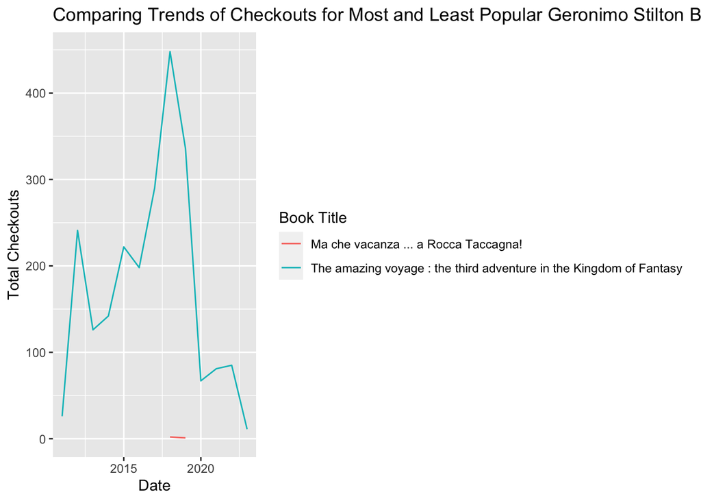

### Second Trends Over Time Chart

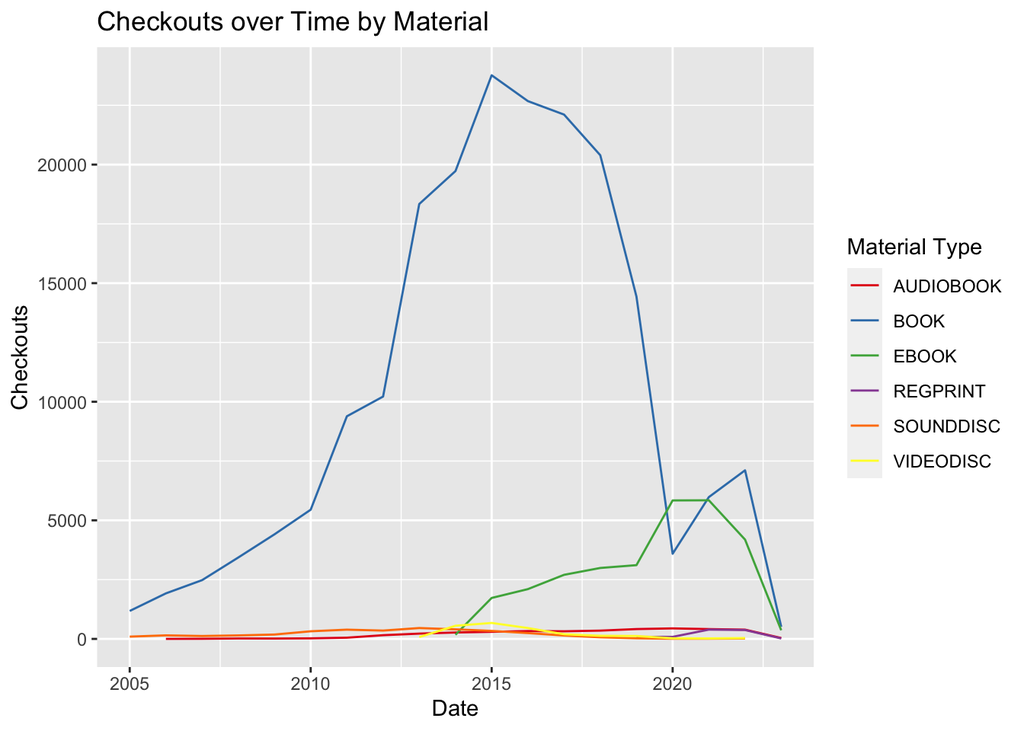

The second chart shows the trends between the material types over time for the Geronimo Stilton series books. It was designed to show trends in people’s preferences in material. From the chart we can se as the physical copy declined, the eBook checkouts increased. However, we can see both decreasing in the last couple years. The rest of the materials have checked out at a pretty steady rate.

### Chart of Most Popular Books

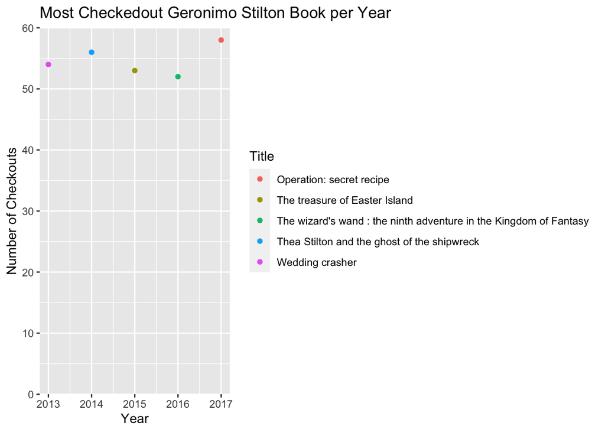